# iDEP: Investigating Differentially Expressed Genes

## If this site has contributed to your work, please cite our article:

Ge, S.X., Son, E.W. & Yao, R. iDEP: an integrated web application for differential expression and pathway analysis of RNA-Seq data. BMC Bioinformatics 19, 534 (2018). https://doi.org/10.1186/s12859-018-2486-6

## Summary

Read Counts data were analyzed using iDEP v2.4.4. The data was first filtered to remove reads below 0.5 CPM in at least 1 sample. Then the data was transformed with EdgeR using a pseudocount of 4. Missing values were imputed using geneMedian.

After mapping, there are 32833 unique genes in 158 samples. Of the 24127 genes passed filter, 24127 were converted to Ensembl/STRING gene IDs in our database. The remaining 0 genes were kept in the data using original IDs.

Differential expression analysis was performed using DESeq2 with an FDR cutoff of 0.1 and a minimum fold-change threshold of 2. Standard Wald test was used and independent filtering was enabled.

## Selected Comparison: Radiation_Dose_cGy10000-Radiation_Dose_cGy0

Up-regulated genes: 615

Down-regulated genes: 191

## Top Up-regulated Genes

```r
if (!is.null(params$up_genes_table) && nrow(params$up_genes_table) > 0) {
  kbl(params$up_genes_table, escape = FALSE) %>%
    kable_classic(full_width = FALSE, html_font = "Cambria")
} else {
  print("No up-regulated genes found for this comparison.")
}
```

| Symbol | Ensembl ID | log2 FC | Adj. P-value | Description |
| --- | --- | --- | --- | --- |
| AT1G07500 | AT1G07500 | 20.043 | 1.43e-68 | Uncharacterized protein |
| AT5G01645 | AT5G01645 | 14.836 | 4.39e-19 | NcRNA |
| AT4G06685 | AT4G06685 | 13.042 | 6.73e-05 | NcRNA |
| AT1G05562 | AT1G05562 | 11.898 | 1.31e-02 | NcRNA |
| GMD1 | AT5G66280 | 11.321 | 1.07e-20 | GDP-D-mannose 4,6-dehydratase 1 |
| AT1G09053 | AT1G09053 | 8.693 | 6.21e-06 | NcRNA |
| AT1G20750 | AT1G20750 | 7.820 | 7.43e-17 | RAD3-like DNA-binding helicase protein |
| AT5G07165 | AT5G07165 | 7.550 | 6.78e-10 | Uncharacterized protein |
| AT4G25330 | AT4G25330 | 7.123 | 6.20e-09 | SAWADEE protein |
| AT3G27630 | AT3G27630 | 6.607 | 1.55e-24 | Cyclin-dependent kinase inhibitor SMR3-like protein |
| NAC085 | AT5G14490 | 5.830 | 3.01e-13 | NAC domain containing protein 85 |
| AT5G51190 | AT5G51190 | 5.430 | 6.47e-08 | Integrase-type DNA-binding superfamily protein |
| AT4G05380 | AT4G05380 | 5.348 | 4.93e-12 | P-loop nucleoside triphosphate hydrolase superfamily protein |
| DRM1 | AT5G15380 | 5.343 | 1.63e-11 | Domains rearranged methylase 1 |
| AT3G12410 | AT3G12410 | 5.185 | 3.91e-15 | Polynucleotidyl transferase, ribonuclease H-like superfamily protein |
| DRP4C | AT1G60500 | 5.055 | 1.65e-08 | Dynamin related protein 4C |
| TIM17-1 | AT1G20350 | 4.974 | 6.05e-14 | Translocase inner membrane subunit 17-1 |
| AT3G29340 | AT3G29340 | 4.825 | 1.30e-06 | Zinc finger (C2H2 type) family protein |
| AT1G21528 | AT1G21528 | 4.780 | 1.06e-06 | Uncharacterized protein |
| AT2G24255 | AT2G24255 | 4.773 | 1.28e-09 | LOW protein: F-box/kelch-repeat protein |
| AT5G60250 | AT5G60250 | 4.749 | 1.02e-21 | Zinc finger (C3HC4-type RING finger) family protein |
| SK9 | AT3G21850 | 4.731 | 3.28e-03 | SKP1-like 9 |
| VIM4 | AT1G66040 | 4.635 | 3.93e-07 | Zinc finger (C3HC4-type RING finger) family protein |
| AT3G56920 | AT3G56920 | 4.564 | 5.15e-05 | DHHC-type zinc finger family protein |
| AT5G51585 | AT5G51585 | 4.272 | 1.56e-06 | Uncharacterized protein |
| PUM12 | AT5G56510 | 4.253 | 1.37e-05 | Pumilio 12 |
| AT2G18193 | AT2G18193 | 4.238 | 4.34e-14 | P-loop containing nucleoside triphosphate hydrolases superfamily protein |
| ZAT7 | AT3G46090 | 4.221 | 7.37e-12 | C2H2 and C2HC zinc fingers superfamily protein |
| AT1G30170 | AT1G30170 | 4.211 | 2.18e-04 |  |
| XRI1 | AT5G48720 | 4.152 | 1.44e-19 | X-ray induced transcript 1 |
| AT4G22960 | AT4G22960 | 4.112 | 5.03e-09 | FAM63A-like protein (DUF544) |
| HDG4 | AT4G17710 | 4.029 | 1.39e-09 | Homeodomain GLABROUS 4 |
| AT3G10930 | AT3G10930 | 4.024 | 1.35e-19 | Uncharacterized protein |
| AT3G48770 | AT3G48770 | 4.006 | 4.47e-13 | ATP/DNA binding protein |
| AT3G61090 | AT3G61090 | 3.974 | 2.17e-10 | Putative endonuclease or glycosyl hydrolase |
| TPS04 | AT1G61120 | 3.957 | 9.18e-03 | Terpene synthase 04 |
| AT1G18010 | AT1G18010 | 3.952 | 4.65e-02 | Major facilitator superfamily protein |
| AT1G44130 | AT1G44130 | 3.885 | 5.66e-07 | Eukaryotic aspartyl protease family protein |
| AT3G09870 | AT3G09870 | 3.833 | 1.42e-05 | SAUR-like auxin-responsive protein family |
| WRKY46 | AT2G46400 | 3.776 | 1.38e-16 | WRKY DNA-binding protein 46 |
| CRK6 | AT4G23140 | 3.766 | 5.83e-07 | Cysteine-rich RLK (RECEPTOR-like protein kinase) 6 |
| SK10 | AT3G21860 | 3.735 | 1.63e-03 | SKP1-like 10 |
| AT1G32570 | AT1G32570 | 3.726 | 1.16e-13 | Uncharacterized protein |
| TRFL10 | AT5G03780 | 3.688 | 1.88e-19 | TRF-like 10 |
| AT1G27890 | AT1G27890 | 3.671 | 3.87e-05 | Polynucleotidyl transferase, ribonuclease H-like superfamily protein |
| AT1G26240 | AT1G26240 | 3.648 | 1.08e-03 | Proline-rich extensin-like family protein |
| AT3G58270 | AT3G58270 | 3.634 | 2.80e-17 | Phospholipase-like protein (PEARLI 4) with TRAF-like domain protein |
| AT1G06587 | AT1G06587 | 3.567 | 1.42e-07 | NcRNA |
| AT3G45730 | AT3G45730 | 3.534 | 3.95e-12 | Uncharacterized protein |
| CYP96A11 | AT4G39500 | 3.524 | 3.39e-08 | Cytochrome P450, family 96, subfamily A, polypeptide 11 |

## Top Down-regulated Genes

```r
if (!is.null(params$down_genes_table) && nrow(params$down_genes_table) > 0) {
  kbl(params$down_genes_table, escape = FALSE) %>%
    kable_classic(full_width = FALSE, html_font = "Cambria")
} else {
  print("No down-regulated genes found for this comparison.")
}
```

| Symbol | Ensembl ID | log2 FC | Adj. P-value | Description |
| --- | --- | --- | --- | --- |
| AT4G09250 | AT4G09250 | -17.521 | 6.03e-03 | SPla/RYanodine receptor (SPRY) domain-containing protein |
| AT2G09785 | AT2G09785 | -16.316 | 2.07e-08 | NcRNA |
| AT5G43490 | AT5G43490 | -13.634 | 3.58e-10 | Myb-like protein X |
| AT1G04163 | AT1G04163 | -11.394 | 1.08e-04 | NcRNA |
| AT1G05767 | AT1G05767 | -10.711 | 2.34e-14 | S-adenosyl-L-methionine-dependent methyltransferases superfamily protein |
| ADT6 | AT1G08250 | -4.278 | 1.90e-05 | Arogenate dehydratase 6 |
| AT3G51070 | AT3G51070 | -3.824 | 1.65e-02 | S-adenosyl-L-methionine-dependent methyltransferases superfamily protein |
| AT4G06870 | AT4G06870 | -3.574 | 4.63e-02 | NcRNA |
| ATEXO70G2 | AT1G51640 | -3.388 | 7.26e-02 |  |
| AT4G06705 | AT4G06705 | -2.852 | 3.52e-02 | NcRNA |
| AT5G06505 | AT5G06505 | -2.710 | 5.39e-03 | NcRNA |
| AT5G40800 | AT5G40800 | -2.517 | 2.57e-04 | Uncharacterized protein |
| HB21 AT2G18550 | AT2G18550 | -2.499 | 1.09e-02 | Homeobox protein 21 |
| AT1G07737 | AT1G07737 | -2.484 | 7.85e-02 | NcRNA |
| AT2G08660 | AT2G08660 | -2.471 | 1.26e-02 | NcRNA |
| AT4G20970 | AT4G20970 | -2.346 | 4.20e-02 | Basic helix-loop-helix (bHLH) DNA-binding superfamily protein |
| AT5G06695 | AT5G06695 | -2.272 | 1.45e-02 | NcRNA |
| ENODL13 | AT5G25090 | -2.248 | 1.89e-05 | Early nodulin-like protein 13 |
| AT1G23160 | AT1G23160 | -2.169 | 9.26e-03 | Auxin-responsive GH3 family protein |
| HAI3 | AT2G29380 | -2.167 | 7.18e-02 | Highly ABA-induced PP2C protein 3 |
| AT3G12870 | AT3G12870 | -2.154 | 4.27e-07 | Uncharacterized protein |
| AT4G14819 | AT4G14819 | -2.145 | 1.70e-02 |  |
| AT5G56120 | AT5G56120 | -2.103 | 9.88e-08 | RNA polymerase II elongation factor |
| AT5G15500 | AT5G15500 | -2.057 | 5.12e-02 | Ankyrin repeat family protein |
| AT3G51280 | AT3G51280 | -2.025 | 3.45e-06 | Tetratricopeptide repeat (TPR)-like superfamily protein |
| AT5G45700 | AT5G45700 | -2.003 | 1.36e-05 | Haloacid dehalogenase-like hydrolase (HAD) superfamily protein |
| AT5G02865 | AT5G02865 | -1.993 | 1.34e-02 | NcRNA |
| HSFA6A | AT5G43840 | -1.976 | 7.96e-02 | Heat shock transcription factor A6A |
| ENODL15 | AT4G31840 | -1.963 | 4.48e-06 | Early nodulin-like protein 15 |
| AT1G08440 | AT1G08440 | -1.949 | 7.77e-02 | Aluminum activated malate transporter family protein |
| AT2G42110 | AT2G42110 | -1.934 | 8.84e-06 | Uncharacterized protein |
| AT5G24080 | AT5G24080 | -1.877 | 6.54e-02 | Protein kinase superfamily protein |
| AT5G66230 | AT5G66230 | -1.868 | 1.68e-05 | Chalcone-flavanone isomerase family protein |
| AT1G63630 | AT1G63630 | -1.850 | 6.88e-02 | Tetratricopeptide repeat (TPR)-like superfamily protein |
| AT1G05440 | AT1G05440 | -1.845 | 2.84e-05 | C-8 sterol isomerase |
| AT5G50360 | AT5G50360 | -1.820 | 9.20e-02 | Von willebrand factor A domain protein |
| AT2G04205 | AT2G04205 | -1.818 | 7.89e-02 | NcRNA |
| AT4G35690 | AT4G35690 | -1.817 | 1.78e-02 |  |
| AT5G01910 | AT5G01910 | -1.804 | 1.18e-04 | Myelin transcription factor |
| MRLK | AT3G56100 | -1.791 | 9.17e-08 | Meristematic receptor-like kinase |
| AT5G60260 | AT5G60260 | -1.789 | 3.78e-02 | Uncharacterized protein |
| CSLD5 | AT1G02730 | -1.764 | 1.52e-05 | Cellulose synthase-like D5 |
| AT1G16630 | AT1G16630 | -1.756 | 9.33e-06 | Uncharacterized protein |
| ROPGEF6 | AT3G55660 | -1.752 | 6.28e-05 | ROP (rho of plants) guanine nucleotide exchange factor 6 |
| AT5G55680 | AT5G55680 | -1.740 | 4.36e-04 | Glycine-rich protein |
| AT4G09240 | AT4G09240 | -1.735 | 9.21e-02 | NcRNA |
| AT3G02640 | AT3G02640 | -1.705 | 3.48e-05 | Uncharacterized protein |
| AT5G16250 | AT5G16250 | -1.699 | 1.36e-05 | Uncharacterized protein |
| ENODL14 | AT2G25060 | -1.682 | 5.42e-05 | Early nodulin-like protein 14 |
| RPS2 AT4G26090 | AT4G26090 | -1.679 | 5.69e-04 | NB-ARC domain-containing disease resistance protein |

## DEG Heatmap

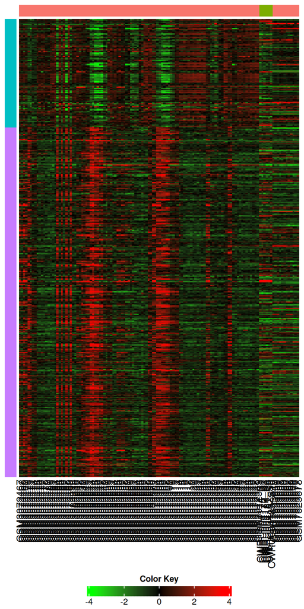

```r
if (!is.null(params$heat_data) && !is.null(params$heat_bar)) {
  heat_colors <- unlist(strsplit(params$heatmap_color_select, "-"))

  deg_heatmap(
    df = params$heat_data,
    bar = params$heat_bar,
    heatmap_color_select = heat_colors,
    cluster_rows = FALSE
  )
}
```

## Volcano Plot

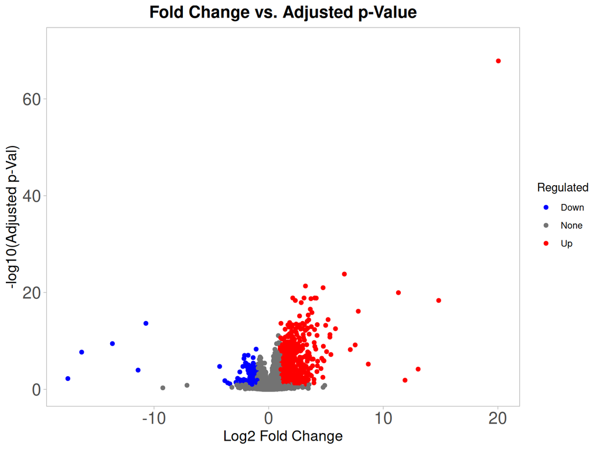

```r
if (!is.null(params$vol_data) && !is.null(params$vol_data$data)) {
  p <- plot_volcano(
    data = params$vol_data$data,
    plot_colors = params$plot_colors,
    anotate_genes = params$gene_labels_volcano
  )
  p <- refine_ggplot2(
    p = p,
    gridline = params$plot_grid_lines,
    ggplot2_theme = params$ggplot2_theme
  )
  print(p)
}
```